# The Promise of Statically Typed Functional Programming: Broader Context and Language Comparison

## Konstantin Läufer (presenter)

## George K. Thiruvathukal

## Joe Kaylor

## Emerging Technologies Lab

## Loyola University Chicago

Workshop on Functional Programming in Quantitative Finance  
The Stevanovich Center for Financial Mathematics  
The University of Chicago

Friday, 20 April 2012

# About Me

## laufer@cs.luc.edu

## http://laufer.cs.luc.edu

Konstantin Läufer is a professor of computer science at Loyola University Chicago. His research interests include programming languages, software architecture, and distributed and pervasive computing, with applications in environmental science and and digital humanities. Konstantin contributes to several open-source projects and serves as department editor for the IEEE/AIP Computing in Science and Engineering Magazine (CiSE). His research has been funded by government agencies and corporations, and he is a co-inventor on two Lucent Technologies patents. He is a consultant on domain-specific tools in the healthcare domain.

# Overview

## Languages and paradigms

## Computational models

## Type systems

## Specific functional languages

## Conclusion

## Cocktails!

# Early History of Programming Languages

- 1940s: machine languages -> binary code
- 1950s: assembly languages -> mnemonics and symbols
- late 1950s: 3GLs -> abstraction and portability
  - FORTRAN
  - ALGOL
  - COBOL
  - LISP

# Some Paradigm-Defining Programming Languages

- 1957: FORTRAN -> imperative style/scientific programming (Backus)
- 1964: APL -> array programming (Iverson)
- 1967: Simula -> Algol-style object-oriented programming (Dahl and Nygaard)
- 1972: C -> imperative style/system programming (Kernigan and Ritchie)
- 1972: Prolog -> logic programming (Colmerauer)
- 1972: Smalltalk -> dynamic object-oriented programming (Kay, Ingalls, Goldberg)
- 1973: Actors -> concurrency/task parallelism (Hewitt, Agha, Hoare et al)
- 1978: ML -> statically typed functional programming (Milner et al)
- 1983: C++ -> C-style object-oriented programming (Stroustrup)

How to choose from this Tower of Babel?

# Dominant Programming Paradigms

- *imperative:* explicit mutable state
- *functional:* (closed or recursive) functions over (usually) immutable values
- *object-oriented:* (public) behavior with (private) state
- *actors*: run to completion, concurrent behavior with local/transient state
- *logic:* queries over facts and rules

# How to Choose?!?

Choose by trying to match the paradigm to the problem.

Some solutions benefit from multiple paradigms and/or languages.

Avoid the hammer/nail syndrome of the late 1990s. More soon.

# Zoom Out: Fundamental Computational Models

- *Turing machine/von-Neumann architecture:* model of the hardware; low-level, unnatural
- *lambda calculus:* model of the computational behavior; simple, mathematical, natural
- *recursion:* direct model of underlying mathematical theory

These three models are equivalent in computational power.

Church-Turing thesis: these three models express anything that is algorithmically computable.

# Lambda Calculus

```
<Exp> ::= <ident>
        | lambda <ident> . <Exp>  -- function abstraction
        | <Exp> <Exp>             -- function application
        | <constant>              -- needed "only in practice"

 (\f (x, y) -> (f x, f y)) (*2) (2, 3) -> (4, 6)
```

Sufficiently powerful to define everything within.

By encoding.

Yes, including recursion.

# Make it Safe: Type Systems in Programming Languages

- A *type system* is a mechanism to classify program fragments according to the type of value they compute. Can be used to ensure values are used as intended.
- A *type error* is a type-related erroneous program behavior.
- *Type safety* is the use of a type system to prevent type errors.

  2 + 3 -> 5

  2 + "3" -> error (possible in C)

  3[4] -> error (possible in C with cast)

# Type System Dimensions

- *static* versus *dynamic*
- *strong* versus *weak*
- *implicit/inferred* versus *explicit*

# Static Type Safety

- The use of a *static* and *strong* type system to prevent type errors at run time.
- Benefits
  - early detection of logical errors "when things don't fit together"
  - do not need to keep type information around at run time -> performance!!
- Challenge
  - keep it from feeling like a straightjacket to the programmer

# Timeline of the Language/Type System Pendulum

- Since mid 1980s: statically typed OO languages: C++, Java, C#
  - want *type safety* and *performance*
  - language monoculture trap: started to focus on libraries and frameworks instead of languages
- Since late 1990s: dynamic languages: Perl, Python, Ruby
  - wanted *productivity* (expressiveness, flexibility, extensibility, etc.)
  - build confidence in correctness through extensive testing (TDD)
  - performance? avoid bottleneck by using as glue for C/C++ libraries
- *Back* since late 2000s: statically typed functional languages: ML and its descendants F#, Haskell, and OCaml; Scala
  - want type safety, performance, *and* agility
  - want better support for multi-core hardware

# ThoughtWorks Technology Radar: Languages Section

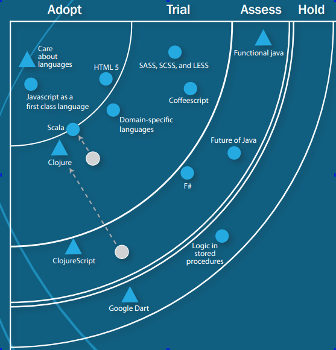

Languages

# Main Statically Typed Contenders: Haskell, F#, Scala

- Haskell: ML descendant, but lazy and without mutable state, no OO
- Scala: Java-based, mutable and immutable state, eager, functional on top of OO
- F#: OCaml descendant, mutable and immutable state, eager, OO on top of functional

All have powerful type systems, but Haskell the most.

All have support for concurrency.

# Interesting Dynamically Typed Contenders

- Clojure: focus on concurrency and high performance
- Erlang: focus on scalability and soft real-time support
- JavaScript: new front ends (e.g., CoffeeScript), becoming a popular target VM

# Running Example: Process Tree

Transform this

```
laufer   20736 25090  0 Apr16 pts/5    00:00:00 /bin/bash
...
laufer   21274 20736  0 Apr16 pts/5    00:00:01 emacs -nw test2bb.txt
laufer   21281 21274  0 Apr16 ?        00:00:00 /usr/bin/aspell -a -m -B --encoding=utf-8
...
laufer   25090     1  0 Apr15 ?        00:01:18 guake -OO /usr/lib/guake/guake.py
...
laufer   28849 25090  0 11:24 pts/9    00:00:00 /bin/bash
```

to this

```
 25090: guake -OO /usr/lib/guake/guake.py
  20736: /bin/bash
   21274: emacs -nw test2bb.txt
    21281: /usr/bin/aspell -a -m -B --encoding=utf-8
  28849: /bin/bash
```

Edge reversal!

# In Java

```
private final Map<Integer, String> pMap = new HashMap<Integer, String>();
private final Map<Integer, List<Integer>> tMap = new HashMap<Integer, List<Integer>>();

    String line = null;
    while ((line = in.readLine()) != null) {
        final Process p = parser.parseString(line);
        pMap.put(p.pid, p.cmd);
        if (! tMap.containsKey(p.ppid))
            tMap.put(p.ppid, new ArrayList<Integer>(CHILD_LIST_SIZE));

// now print tMap as a tree
```

Languages with name-based typing require a name for every type! Verbose, not agile.

# In a Typical Dynamic Language

```
pMap = new HashMap
tMap = new HashMap

    line = null;
    while ((line = in.readLine()) != null) {
        p = processParser.parseString(line);
        pMap.put(p.pid, p.cmd);
        if (! tMap.containsKey(p.ppid))
            tMap.put(p.ppid, new ArrayList(CHILD_LIST_SIZE));

// now print tMap as a tree
```

Fictitious language. (I kind of leapfrogged over dynamic languages.)

Type erasure of Java example.

# In F# Using .NET Collections

```
let cMap = new Dictionary<int, String>()
let tMap = new Dictionary<int, ICollection<int>>()
let bOut = new StreamWriter(new BufferedStream(Console.OpenStandardOutput()))

let mutable line = Console.ReadLine()
while line <> null do
    let (words, pid, ppid) = // ...parse from line...
    cMap.[pid] <- line.Substring(iCmd)
    if not (tMap.ContainsKey(ppid)) then
        tMap.[ppid] <- new List<int>(8)
    tMap.[ppid].Add(pid)
    line <- Console.ReadLine()

// now print tMap as a tree
```

Looks like a C# program.

Performs like a C# program!

# In F# Using F#'s Built-In Collections

```
let rec lines = seq {
    let line = Console.ReadLine()
    if line <> null then yield line ; yield! lines
}

let parse (line: string) = // ...

let ps = lines |> Seq.map parse |> List.ofSeq
let cMap = ps |> List.map (fun (pid, _, cmd) -> (pid, cmd)) |> Map.ofList
let tMap = ps |> Seq.ofList |> Seq.groupBy (fun(_, ppid, _) -> ppid) |> Map.ofSeq

// now print tMap as a tree
```

Compose computations at the collection level.

The only mutable state is I/O.

About 50% performance overhead over previous version. In part because these maps are tree-based.

# In Scala

```
val lines = scala.io.Source.fromInputStream(System.in).getLines
val out = new BufferedWriter(new OutputStreamWriter(System.out), IO_BUF_SIZE);
val parse = parseLine(lines.next())

val ps = lines map parse toList
val pmap = ps map { case (pid, _, cmd) => (pid, cmd) } toMap
val tmap = ps groupBy (_._2)

// now print tMap as a tree
```

Compose computations at the collection level.

The only mutable state is I/O.

# In Haskell

```
printProcessTree :: [String] -> [String]
printProcessTree (header : lines) =
  let
    ps = map (parser header) lines
    pmap = IntMap.fromList ps
    tmap = IntMap.fromListWith (++) $ map (\(_, (pid, ppid, _)) -> (ppid, [pid])) ps
    showTrees l i = -- ...convert tmap to strings...
  in
    showTrees 0 0

main :: IO()
main = interact $ unlines . printProcessTree . lines
```

Compose computations at the collection level.

The only mutable state is I/O.

But even this is hidden in `interact` using dependency injection.

# Monadic Style in Haskell

Different example: echo back input lines and print how many were there.

```
mainLoop :: Int -> IO ()
mainLoop count = count `seq` do
  eof <- isEOF
  if eof
    then
      putStrLn $ show count
    else do
      line <- getLine
      putStrLn line
      mainLoop $ count + 1

main :: IO ()
main = mainLoop 0
```

Looks like imperative code.

Mutable state of I/O is safely partitioned into I/O monad.

# Higher-Kinded Typing in Haskell

Haskell has no subtype polymorphism, duck typing, or the like.

But...

```
fmap (*2) (Just 3) -> Just 6

let t = Node 1 [Node 2 [], Node 3 [Node 4 [], Node 5 []]]
fmap (*2) t -> Node 2 [Node 4 [], Node 6 [Node 8 [], Node 10 []]]
```

...it has typeclasses for systematic function overloading.

```
class Functor f where
  fmap :: Functor f => (a -> b) -> f a -> f b
```

Example of an *abstraction over type constructors* (generic types): f is Maybe a, Tree a, etc.

Scala: scalaz

F#: upstream in F*

# So How to Choose?

# Basic Intrinsic Criteria

- Readability
- Writability/Productivity
- Reliability
- Cost
- Portability
- Generality
- Foundational soundness
- REPL for exploratory programming
- Support for internal and/or external domain-specific languages

All three languages score very similarly on all of these!

# Matt's Extrinsic Criteria from Consulting Firm

- Current expertise in workforce
- Level of local area expertise (Can we hire around here?)
- Cost of productive developer ("We don't want the best if we can get good enough for half the price")
- Cost of training current workforce
- Cost of migrating infrastructure
- Cost of developer tools
- Performance and scalability
- Ability to offshore
- Community strength (blogs, meetups, conventions)
- Visibility of language (CIOs like saying they are part of up-and-coming languages)
- Support (Documentation, Consultants, paid ticket support)

# Other Interesting Criteria

- Performance
- Support for concurrent and parallel programming
- Ecosystem
  - tools
  - "batteries included" (standard libraries)
  - target virtual machine/interoperability
- Major projects
- Community including books, industry backing, etc.
- Other tools
- "Use what your friends use"

# Popularity of Languages

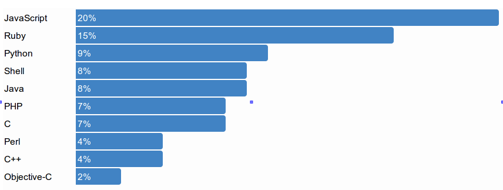

Top languages on GitHub

- based on site statistics; Haskell 16, Scala 17, F# 41

[Tiobe index at www.tiobe.com](http://www.tiobe.com/index.php/content/paperinfo/tpci)

- based on queries of eight search engines; Haskell 37, F# 39, Scala 45

# Performance

- shootout.alioth.debian.org

  ```
  language                        25%     median  75%
  C++ GNU g++     1.00    1.00    1.10    1.26    1.68    2.28    2.28
  Java 7 -server  1.40    1.40    1.59    1.90    2.14    2.97    4.76
  Scala           1.39    1.39    1.94    2.78    3.44    5.70    10.98
  Haskell GHC     1.53    1.53    2.60    2.80    4.36    7.00    15.15
  C# Mono         1.60    1.60    2.62    3.08    7.12    13.88   14.21
  Clojure         2.05    2.05    3.58    5.19    8.28    12.07   12.07
  F# Mono         2.97    2.97    3.16    5.33    8.92    17.57   37.80
  Erlang HiPE     5.17    5.17    7.99    10.79   15.44   26.61   41.54
  Ruby 1.9        4.67    4.67    11.74   53.29   101.33  235.71  356.61
  ```

- our own process tree benchmarks

  ```
  factor 1:  C, C++ (cstdio)
  factor 2:  C#, C++ (iostream), F# (.NET collections)
  factor 3:  Java (real time: 2.5), F# (built-in collections)
  factor 6:  Scala (real time: 5)
  factor 20: Haskell
  ```

Both using Mono on Linux.

# Assessment of Main Contenders: Haskell

- very powerful type system
- extensive standard library
- parser combinators for external DSLs
- cohesive, active community
- development tools not very mature

# Assessment of Main Contenders: Scala

- parser combinators for external DSLs
- actors
- typesafe stack: akka middleware, play web app framework, spray web services toolkit
- high project activity
- Java interoperability
- decent development tools

# Assessment of Main Contenders: F#

- CLR performance advantages over JVM for scientific/financial computing
- numerical computing, units of measure
  - [reference with example](http://msdn.microsoft.com/en-us/library/dd233243.aspx)
- fslex/fsyacc lexer/parser generators for external DSLs
- asynchronous computing (actors), data and task parallelism
  - [example: parallel matrix multiplication](http://msdn.microsoft.com/en-us/library/hh304369.aspx)
- supported product status
- .NET interoperability
- excellent development tools
- cross-platform support getting there
- growing community

# Conclusion

- Why statically typed functional languages?
  - early detection of errors
  - performance
  - natural choice of paradigm
- Why F#?
  - excellent pragmatic choice for scientific/financial computing

# Questions, Discussion, Cocktails...